# HDAT9600 Chapter 5 TBLA

Victor Hui, Haran Nathan, Maathumai Ranjan, Meg Stevens

## Instructions

As a team, you should complete the tasks described below, in the spaces provided. Don’t hesitate to ask each other and the course instructors for help (use the OpenLearning environment to do that) — remember that these are learning activities and we learn most when we share.

## Task 1 (7 marks)

In this task, you will be using the `nodal` dataset which comes with the *boot* package for R which you should already have installed — it should have been installed automatically when you installed the package containing the HDAT9600 chapter 2 tutorial. If not, install it now using the Packages tab in RStudio or the `install.packages()` function at R console prompt.

The manual (help) page for the `nodal` dataset states the following:

> The nodal data frame has 53 rows and 7 columns.

> The treatment strategy for a patient diagnosed with cancer of the prostate depend highly on whether the cancer has spread to the surrounding lymph nodes. It is common to operate on the patient to get samples from the nodes which can then be analysed under a microscope but clearly it would be preferable if an accurate assessment of nodal involvement could be made without surgery.

> For a sample of 53 prostate cancer patients, a number of possible predictor variables were measured before surgery. The patients then had surgery to determine nodal involvement. It was required to see if nodal involvement could be accurately predicted from the predictor variables and which ones were most important.

The variables in the data set are all binary variables:

**`m`**

A column of ones (this column is deleted in the set-up code below, so ignore it henceforth.)

**`r`**

An indicator of nodal involvement.

**`aged`**

The patients age dichotomized into less than 60 (0) and 60 or over 1.

**`stage`**

A measurement of the size and position of the tumour observed by palpitation with the fingers via the rectum. A value of 1 indicates a more serious case of the cancer.

**`grade`**

Another indicator of the seriousness of the cancer, this one is determined by a pathology reading of a biopsy taken by needle before surgery. A value of 1 indicates a more serious case of the cancer.

**`xray`**

A third measure of the seriousness of the cancer taken from an X-ray reading. A value of 1 indicates a more serious case of the cancer.

**`acid`**

The level of acid phosphatase in the blood serum.

```r
# this loads the nodal dataset and makes it available for code in
# subsequent code chunks.
data(nodal, package="boot")
nodal$m <- NULL
```

### 1.a

Carry out a brief exploratory data analysis, using the `summary()` function on the whole data frame, and also plotting it as a matrix image. Ensure that the columns in the data frame are plotted as columns in the matrix image. Hint: `image()`. Commentary is optional. (1 mark)

```r
# insert your R code (with comment lines if you wish) here
summary(nodal)
```

```
##        r               aged            stage            grade
##  Min.   :0.0000   Min.   :0.0000   Min.   :0.0000   Min.   :0.0000
##  1st Qu.:0.0000   1st Qu.:0.0000   1st Qu.:0.0000   1st Qu.:0.0000
##  Median :0.0000   Median :0.0000   Median :1.0000   Median :0.0000
##  Mean   :0.3774   Mean   :0.4528   Mean   :0.5094   Mean   :0.3962
##  3rd Qu.:1.0000   3rd Qu.:1.0000   3rd Qu.:1.0000   3rd Qu.:1.0000
##  Max.   :1.0000   Max.   :1.0000   Max.   :1.0000   Max.   :1.0000
##       xray             acid
##  Min.   :0.0000   Min.   :0.000
##  1st Qu.:0.0000   1st Qu.:0.000
##  Median :0.0000   Median :1.000
##  Mean   :0.3019   Mean   :0.566
##  3rd Qu.:1.0000   3rd Qu.:1.000
##  Max.   :1.0000   Max.   :1.000
```

```r
head(nodal)
```

```
##   r aged stage grade xray acid
## 1 1    0     1     1    1    1
## 2 1    0     1     1    1    1
## 3 1    0     1     1    1    1
## 4 1    0     1     1    1    1
## 5 1    0     1     1    1    1
## 6 0    0     1     1    1    1
```

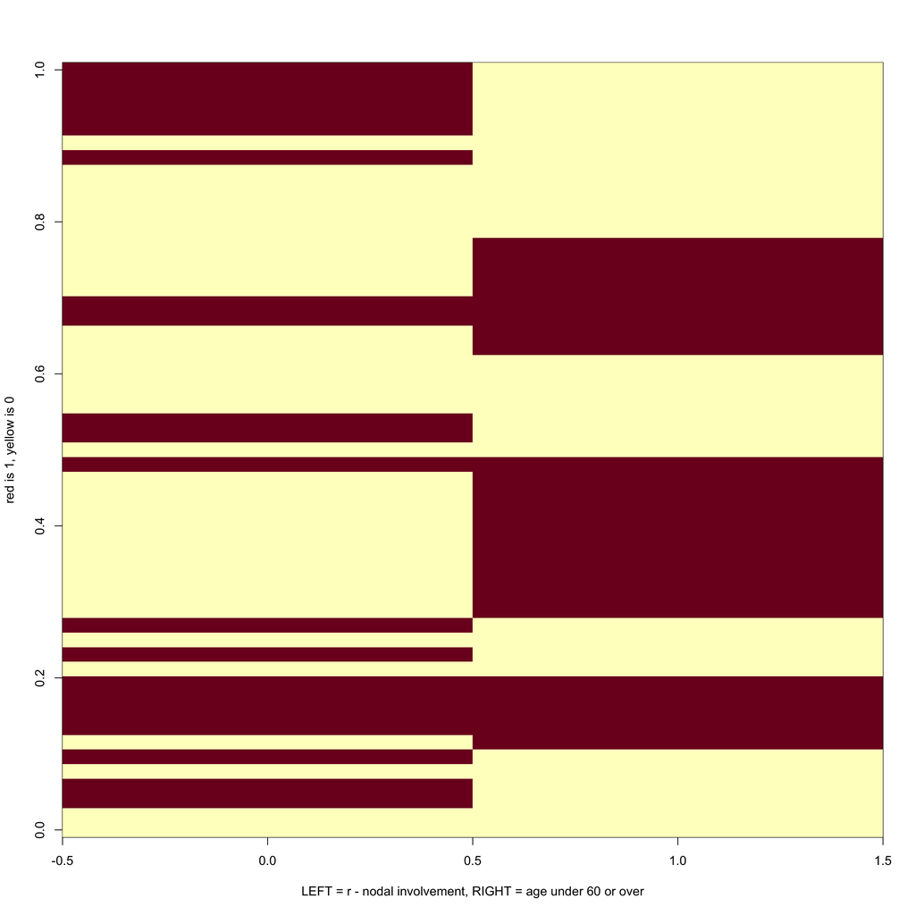

```r
# function to rotate matrices, taken from Chapter 1 section_3.rmd
rotate <- function(x) t(apply(x, 2, rev))

image(rotate(matrix(c(nodal$r,nodal$aged),nrow=53,byrow=FALSE)),
      xlab="LEFT = r - nodal involvement, RIGHT = age under 60 or over",
      ylab="red is 1, yellow is 0")
```

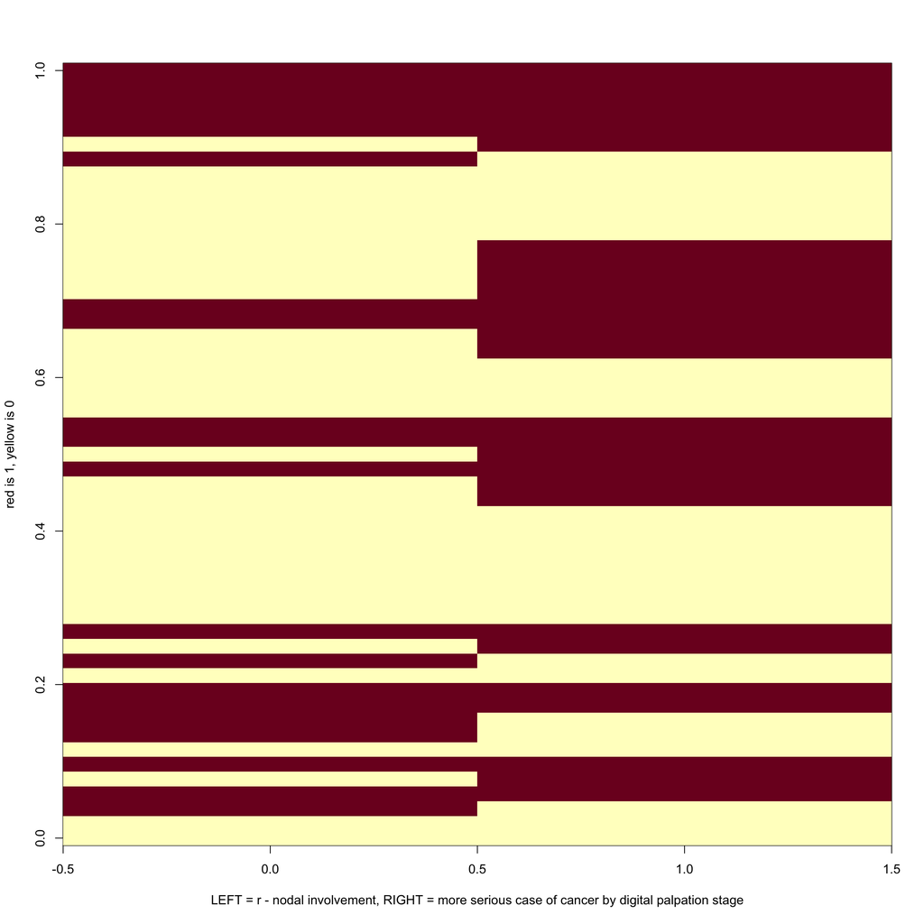

```r
# each band of the image represents one data row

image(rotate(matrix(c(nodal$r,nodal$stage),nrow=53,byrow=FALSE)),
      xlab="LEFT = r - nodal involvement, RIGHT = more serious case of cancer by digital palpation stage",
      ylab="red is 1, yellow is 0")
```

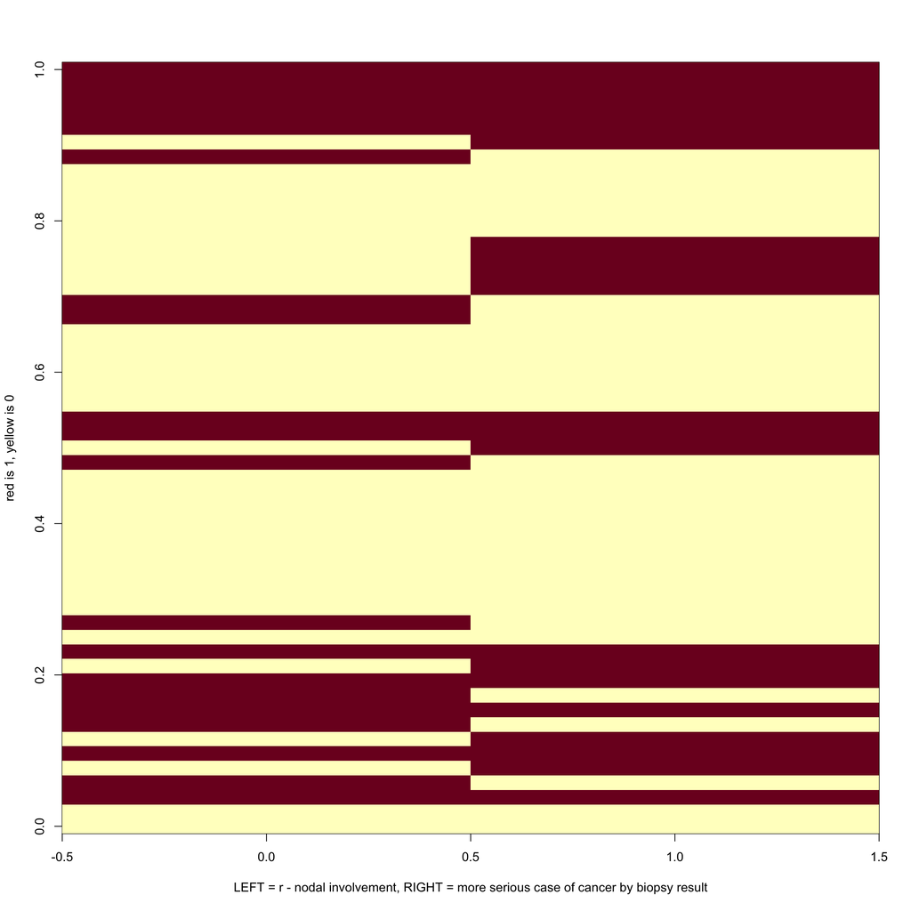

```r
image(rotate(matrix(c(nodal$r,nodal$grade),nrow=53,byrow=FALSE)),
      xlab="LEFT = r - nodal involvement, RIGHT = more serious case of cancer by biopsy result",
      ylab="red is 1, yellow is 0")
```

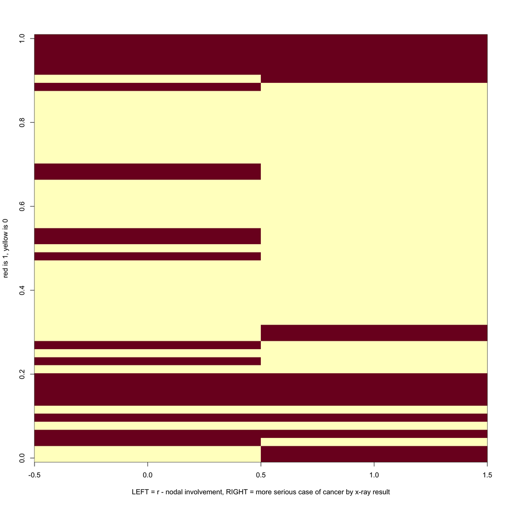

```r
image(rotate(matrix(c(nodal$r,nodal$xray),nrow=53,byrow=FALSE)),
      xlab="LEFT = r - nodal involvement, RIGHT = more serious case of cancer by x-ray result",
      ylab="red is 1, yellow is 0")
```

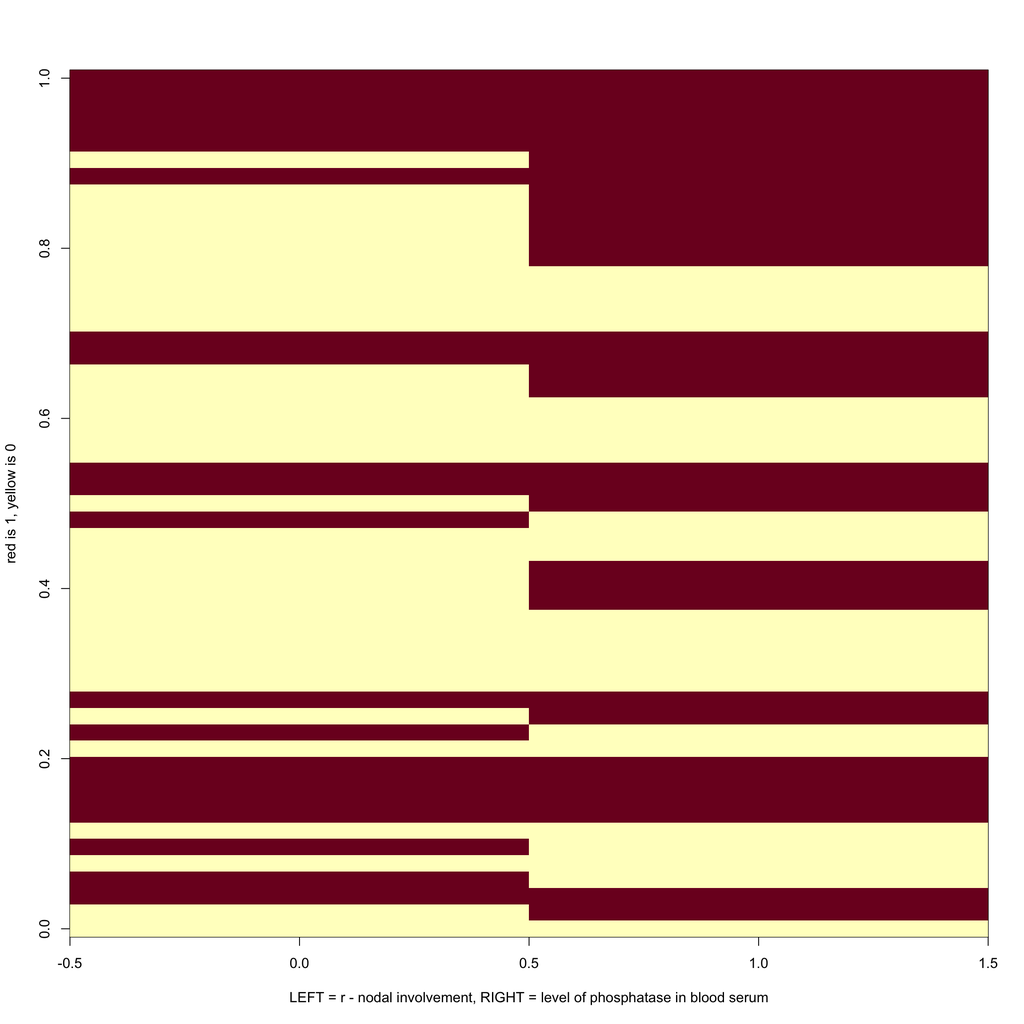

```r
image(rotate(matrix(c(nodal$r,nodal$acid),nrow=53,byrow=FALSE)),
      xlab="LEFT = r - nodal involvement, RIGHT = level of phosphatase in blood serum",
      ylab="red is 1, yellow is 0")
```

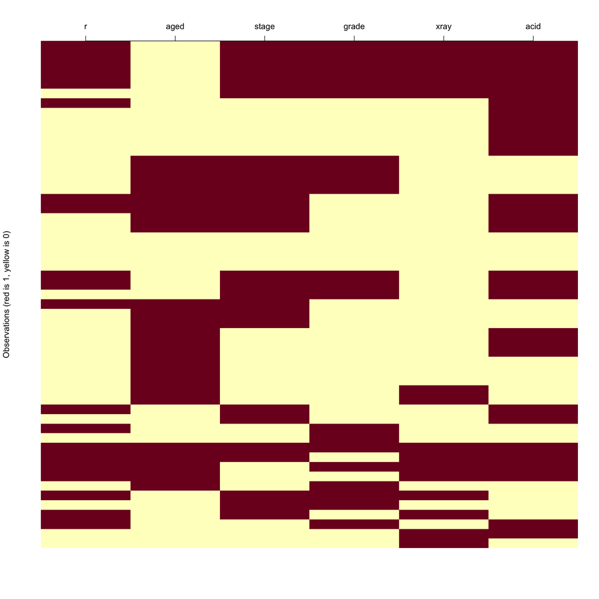

```r
# plotting whole data frame as an image
image(1:ncol(nodal), 1:nrow(nodal), rotate(as.matrix(nodal)), axes=FALSE, ylab="Observations (red is 1, yellow is 0)", xlab="")

# add axis labels, note: 3 <- above, 2 <- left
image(1:ncol(nodal), 1:nrow(nodal), rotate(as.matrix(nodal)), axes=FALSE, add=TRUE)
axis(3, at=1:ncol(nodal), labels=colnames(nodal))
```

All data points are binary.  
r - nodal involvement is the outcome variable and the others would be predictors  
Matrix images - each band of the image represents one data row  
None of the predictors are obviously more predictive than the others - based on eyeball matching of colours  
Perhaps there are more individuals with 2 or more predictor variables with nodal involvement than without

### 1.b

Fit an appropriate regression model with nodal outcome (the `r` variable) as the outcome and all the other variables as predictors. Display the model summary and comment on it, in particular whether there is evidence that any of the predictors are related to the outcome. (2 marks)

```r
# insert your R code (with comment lines if you wish) here
nodal_mod <- glm(r ~ aged + stage + grade + xray + acid, family=binomial, data=nodal)
summary(nodal_mod)
```

```
##
## Call:
## glm(formula = r ~ aged + stage + grade + xray + acid, family = binomial,
##     data = nodal)
##
## Deviance Residuals:
##     Min       1Q   Median       3Q      Max
## -2.3317  -0.6653  -0.2999   0.6386   2.1502
##
## Coefficients:
##             Estimate Std. Error z value Pr(>|z|)
## (Intercept)  -3.0794     0.9868  -3.121   0.0018 **
## aged         -0.2917     0.7540  -0.387   0.6988
## stage         1.3729     0.7838   1.752   0.0799 .
## grade         0.8720     0.8156   1.069   0.2850
## xray          1.8008     0.8104   2.222   0.0263 *
## acid          1.6839     0.7915   2.128   0.0334 *
## ---
## Signif. codes:  0 '***' 0.001 '**' 0.01 '*' 0.05 '.' 0.1 ' ' 1
##
## (Dispersion parameter for binomial family taken to be 1)
##
##     Null deviance: 70.252  on 52  degrees of freedom
## Residual deviance: 47.611  on 47  degrees of freedom
## AIC: 59.611
##
## Number of Fisher Scoring iterations: 5
```

```r
# str(nodal_mod)
# this gives the structure of the model object, but also prints a long list of stuff, hence commented out unless required
```

Xray and Acid predictors are statistically significant. Age, Stage and Grade are not statistically significant. Based on a statistically significant P value of p=0.05

### 1.c

Fit a smaller model that removes the two least significant variables in the model fitted in task 1.b. Can this smaller model be used in preference to the larger model? Justify your answer by creating an appropriate analysis of deviance. (2 marks)

```r
# insert your R code (with comment lines if you wish) here
nodal_small <- glm(r ~ stage + xray + acid, family=binomial, data=nodal)
summary(nodal_small)
```

```
##
## Call:
## glm(formula = r ~ stage + xray + acid, family = binomial, data = nodal)
##
## Deviance Residuals:
##     Min       1Q   Median       3Q      Max
## -2.1231  -0.6620  -0.3039   0.4710   2.4892
##
## Coefficients:
##             Estimate Std. Error z value Pr(>|z|)
## (Intercept)  -3.0518     0.8420  -3.624  0.00029 ***
## stage         1.6453     0.7297   2.255  0.02414 *
## xray          1.9116     0.7771   2.460  0.01390 *
## acid          1.6378     0.7539   2.172  0.02983 *
## ---
## Signif. codes:  0 '***' 0.001 '**' 0.01 '*' 0.05 '.' 0.1 ' ' 1
##
## (Dispersion parameter for binomial family taken to be 1)
##
##     Null deviance: 70.252  on 52  degrees of freedom
## Residual deviance: 49.180  on 49  degrees of freedom
## AIC: 57.18
##
## Number of Fisher Scoring iterations: 5
```

```r
# Comparing the two models
print(anova(nodal_mod,nodal_small, test="Chi"))
```

```
## Analysis of Deviance Table
##
## Model 1: r ~ aged + stage + grade + xray + acid
## Model 2: r ~ stage + xray + acid
##   Resid. Df Resid. Dev Df Deviance Pr(>Chi)
## 1        47     47.611
## 2        49     49.180 -2  -1.5696   0.4562
```

The two least significant values are aged and grade  
When removed, the three predictors all become statistically significant P<0.05

### 1.d

Using the smaller model from task 1.c, calculate how much does having a serious x-ray result increase the odds of nodal involvement compared to have a non-serious x-ray result? Provide a 95% confidence interval for the odds. (2 marks)

```r
# insert your R code (with comment lines if you wish) here

# exponents of the betas can be interpreted directly as odds
beta <- nodal_small$coefficients
exp(beta)
```

```
## (Intercept)       stage        xray        acid
##  0.04727439  5.18280478  6.76407713  5.14372785
```

```r
# profile likelihood-based confidence interval using confint function
confint <- confint(nodal_small)
# xray is the third variable
xray_ci <- confint[3,]
exp(xray_ci)
```

```
##    2.5 %   97.5 %
##  1.57967 35.49065
```

### Save and knit

**Reminder**: don’t forget to save this file, to knit it and check that everything works.